# ISA401 Final

Rylee Elling

2026-04-29

## Introduction

This file contains information about the data acquisition, cleaning, transformation, validation, and merging of our final ISA401 project dataset. We acquire data from 6 different sources, culminating in a dataset with 23 data categories and 15 different streaming services.

```r
chat <- ellmer::chat_openai(
  model = "gpt-5-mini-2025-08-07"
)

usethis::edit_r_environ(scope = "project")
```

```
## ✔ Setting active project to "C:/Users/rylee/OneDrive/Desktop/ISA401 Final
##   Project/ISA401 Final Project".
```

```
## ☐ Edit '.Renviron'.
```

```
## ☐ Restart R for changes to take effect.
```

# Import libraries used in the project

```r
library(tidyverse)
library(dplyr)
library(purrr)
library(readr)
library(naniar)
```

## Scraping and Cleaning Insider Monkey Revenue Data

```r
# Use the ellmer package to read the Statista bar chart of the revenue of streaming services, saved as a PNG file.
# Scrape from this image the name of each streaming platform as a string and the revenue as listed in the bar chart as decimal.


# Verify that the Hollywood Reporter site allows web scraping for the path we wish to scrape
# A TRUE result allows web scraping

robotstxt::paths_allowed(
  paths = "/business/business-news/streaming-profit-report-netflix-leads-disney-warner-bros-1236184451/",
  domain = "https://www.hollywoodreporter.com"
)
```

```
##  https://www.hollywoodreporter.com
```

```
## [1] TRUE
```

```r
# Insider Monkey has ranked the top 15 streaming sites and included each sites' revenue. These are spread across 6 different pages


# Start with the bottom 10 ranked sites
# read the html of the site into a variable

hreporter_webpage_top15 <- rvest::read_html("https://www.insidermonkey.com/blog/15-biggest-streaming-and-tv-companies-in-the-us-1192787/")

# Pull the platform names from the website using rvest and the associated html elements

hreporter_webpage_top15 |>
  rvest::html_elements("#post-1192787 > div.clearfix > div > h3 > b") |>
  rvest::html_text() -> rev_10

# convert the text that was scraped into a tibble
platforms_10 <- tibble(Platform = rev_10)

# Clean the tibble by removing the empty row
platforms_10 <- platforms_10[-3, ]


# Pull the revenues from the website
hreporter_webpage_top15 |>
  rvest::html_elements("div > p > b > i") |> rvest::html_text() -> rev_val_10

# convert the scraped text into a tibble and clean by removing the empty row
rev_10 <- tibble(Revenue = rev_val_10)
rev_10 <- rev_10[-4, ]

# combine the tibbles into one data frame that now contains the name and revenue of 10/15 of the top performing streaming sites
# bot_10_revs <- data.frame(platforms_10, rev_10)
revenues <- data.frame(platforms_10, rev_10)



# The 5th ranked streaming site

# read the html of the site into a variable
hreporter_webpage_top5 <- rvest::read_html("https://www.insidermonkey.com/blog/5-biggest-streaming-and-tv-companies-in-the-us-1192786/")

# scrape the platform name
hreporter_webpage_top5 |>
  rvest::html_elements("div.clearfix > div > h3 > b") |>
  rvest::html_text() -> Platform

# scrape the revenue
hreporter_webpage_top5 |>
  rvest::html_elements("div > p > b > i") |> rvest::html_text() -> Revenue

# create a data frame for the 5th ranked platform and its revenue
df <- data.frame(Platform, Revenue)

# combine the dataframes together to get 11/15 of the sites
# bot_10_revs <- rbind(bot_10_revs, df)
revenues <- rbind(revenues, df)

# Function to scrape the remaining 4 pages

# use the page number from a list below to scrape the corresponding page of the remaining platform names and revenue
scrape_monkey <- function(page){
  url <- paste0("https://www.insidermonkey.com/blog/5-biggest-streaming-and-tv-companies-in-the-us-1192786/", page, "/")
  hreporter_webpage <- rvest::read_html(url)
  Sys.sleep(2)

  # scrape the webpage for the platform name
  hreporter_webpage |>
  rvest::html_elements("div.clearfix > div > h3 > b") |>
  rvest::html_text() -> platform

  # scrape the webpage for the revenue
  hreporter_webpage |>
  rvest::html_elements("div > p > b > i") |> rvest::html_text() -> rev

  # put these values into a dataframe, to be returned and combined into the final datframe
  df <- data.frame(Platform = platform, Revenue = rev)

  Sys.sleep(2) #2 seconds

  return(df)

}

# page numbers of the remaining pages needed to be scraped
pages <- c('5','4','3','2')

# loop through the remaining 4 pages and add the names and revenues to complete the dataframe
for (nums in pages){
  df = scrape_monkey(page = nums)
  head(df)
  revenues <- rbind(revenues, df)
}


rev_prompt <- revenues
# Prompts to clean platform names and revenues by removing the bullet point numbers and "Estimated 2022 Revenue: $" and "billion" from the revenues
platform_names <- ellmer::type_object(
  `Platform` = ellmer::type_string(
    description = "The streaming platform name. Write each platform name as a new row. There must be 15 total rows. Keep the original order of the list. Do not order according to the ranked list.
Rules:
1. If the text is written as 'numeric.'X. Y', write Y
2. If the text contains (NYSE:, follow the example below.
Examples:
- '2. Amazon Prime Video' → Amazon Prime Video
- '14. fuboTV Inc. (NYSE:' → fuboTV Inc.
- '3. Disney+ ' → Disney+
"
  ))



platform_revenue <- ellmer::type_object(
`2022 Revenue (billions)` = ellmer::type_number(
    description = "Extract the share of total tv viewing. Write each revenue value as a new row. There should be 15 total rows.
Rules:
1. If the text contains Estimated 2022 Revenue: $X billion, write X
2. If the text contains 2022 Revenue: $Y billion, write Y
Examples:
- '2022 Revenue: $1 billion' → 1
- 'Estimated 2022 Revenue: $2.6 billion' → 2.6
"
  )
)


# Clean the revenues data using the prompts above
revenue_name <- ellmer::parallel_chat_structured(chat, rev_prompt, type = ellmer::type_array(platform_names))
```

```
## [working] (0 + 0) -> 1 -> 1 | ■■■■■■■■■■■■■■■■ 50%
```

```r
revenue_val <- ellmer::parallel_chat_structured(chat, rev_prompt, type = ellmer::type_array(platform_revenue))
```

```
## [working] (0 + 0) -> 1 -> 1 | ■■■■■■■■■■■■■■■■ 50%
```

```r
# collect the cleaned platform names and revenues
revenue <- cbind(revenue_name[[1]], revenue_val[[2]])
```

## Scraping Brandience subscription OTT video viewers Data

```r
# Use the ellmer package to read the Brandience bar chart of the subscription OTT video viewers in the US by streaming service provider, saved as a PNG file.

# Scrape from this image the name of each streaming platform as a string and the OTT as listed in the bar chart as decimal.

ott <- chat$chat_structured(
  ellmer::content_image_file("../Data/project_images/brandience_OTT_views.png"),
  type = ellmer::type_array(ellmer::type_object(
    Platform = ellmer::type_string(
      description = "The name of each of the 12 streaming services listed in the bar chart. Separate each service into a new row. EX: Disney+"
    ),
    `Subscription OTT Video Viewers (Millions)` = ellmer::type_number(
      description = "The video viewers for the streaming service from 2024-2028. Listed in the bar chart right of the blue bar. Separate each revenue into a new row.  EX: 184.2"
    )
  )
))
```

## Scraping AdTechRave/Emarketer Top platforms by ad spending data

```r
# Use the ellmer package to read the Emarketer table of the Top 10 Streaming TV Platforms Ranked by Ad Spending, saved as a PNG file.

# Scrape from this image the name of each streaming platform as a string, the ad spend in 2024 as an integer, the ad spend in 2025 as an integer, and the % change as a decimal.

# Since the table does not have a 2024, 2025, and % change for each column, the corresponding values are not required to be scraped by the AI.

ad_spend <- chat$chat_structured(
  ellmer::content_image_file("../Data/project_images/adtechradar_ad_spending.png"),
  type = ellmer::type_array(ellmer::type_object(
    Platform = ellmer::type_string(
      description = "The name of each of the 10 streaming services listed in the chart. Separate each service into a new row. EX: Disney+"
    ),
    `2024 Ad Spending (Millions)` = ellmer::type_integer(
      description = "The ad spend for the streaming service from 2024 and 2025. Listed in the  chart under the 2024 column name, to the right of each service. Separate each revenue into a new row.  EX: 4386",
    required = FALSE
    ),
    `2025 Ad Spending (Millions)` = ellmer::type_integer(
      description = "The ad spend for the streaming service from 2024 and 2025. Listed in the  chart under the 2025 column name, to the right of each service. Separate each revenue into a new row. EX: 4690",
    required = FALSE
    ),
    `Ad Spending % Change` = ellmer::type_number(
      description = "The change in ad spending from 2025 to 2024 for each streaming service. Listed in the chart under the % change column. Change the percentage to a decimal EX: 7% = 0.07", required = FALSE
    )
  )
))
```

## Scraping watch time data from Statista

```r
# Use the ellmer package to read the Statista double bar chart of the watch times for active users and total adults for varying streaming services.

# Scrape from this image the name of each streaming platform as a string, the watch time of active users as an integer, and the watch time of the total adults as an integer.


watch_time <- chat$chat_structured(
  ellmer::content_image_file("../Data/project_images/statistia_watch_time.png"),
  type = ellmer::type_array(ellmer::type_object(
    Platform = ellmer::type_string(
      description = "The name of each of the 6 streaming services listed in the bar chart. Separate each service into a new row. EX: Disney+"
    ),
    `Active Users Average Daily Watch Time (minutes)` = ellmer::type_integer(
      description = "The time spent in minutes the avg daily viewer watches for each platform. Listed above the left most blue bar charts of each pair. Separate each into a new row.  EX: 63"
    ),

    `Total Adults Average Daily Watch Time (minutes)` = ellmer::type_integer(
      description = "The time spent in minutes the avg daily viewer watches for each platform. Listed above the right most dark bar charts of each pair. Separate each into a new row.  EX: 36"
    )
  )
))
```

## Scraping and Cleaning Ad break data from Streamable

```r
# Verify that the Streamable site allows web scraping for the path we wish to scrape
# A TRUE result allows web scraping

robotstxt::paths_allowed(
  paths = "/how-many-ads-does-each-streaming-service-show",
  domain = "https://thestreamable.com"
)
```

```
##  https://thestreamable.com
```

```
## [1] TRUE
```

```r
# read the html of the site into a variable

streamable_webpage <- rvest::read_html("https://thestreamable.com/how-many-ads-does-each-streaming-service-show")

# scrape all tables on the site by reading the related html elements into a table

streamable_webpage |>
  rvest::html_elements("#content > article > div.markdown-body.width-fit.draft-current-text > table") |>
  rvest::html_table() -> all_tables

# The table created includes rows that hold a tibble of number of breaks per tv or movie, tibble of ad break length for tv or movie, tibble of ads per tv or movie, and tibble of whether ads are presented on kids material.

# Join all of the rows in the table into one large table by joining on Streamer (platform name) and Original Article (unrelated link that is not needed)

# Begin by joining the tibble stored as an element of each list-column of the first two rows (The table created includes columns that hold the table of number of breaks per tv or movie and the ad break length for tv or movie)

big_table = dplyr::left_join(all_tables[[1]], all_tables[[2]], by = c('Streamer', 'Original Article'))

# Repeat for the remaining row, choosing not to include the tibble related to whether ads are presented on kids material.

big_table = dplyr::left_join(big_table, all_tables[[3]], by = c('Streamer', 'Original Article'))


# remove the column containing information about the original article

big_table <- big_table |> dplyr::select(-`Original Article`)

# rename the Streamer column to be Platform to match other dataframes
big_table <- big_table |> rename(Platform = Streamer)

# store the second column of the dataframe as a list in prompts to be used with ellmer below
# this list will contain information about the breaks per 30 minute episode
big_table[[2]] |> as.list() -> prompts

# prompts for the chat to follow to separate the data into 3 columns: Whether the streaming service has ads during the pre-roll, the minumum number of breaks during an episode, and the maximum number of breaks
ep_breaks <- ellmer::type_object(
  `Pre-roll breaks per 30 min episode` = ellmer::type_string(
    description = "Whether the streaming service has ads during the pre-roll or not. EX: No pre-roll "
  ),
  `Minimum breaks per 30 min episode` = ellmer::type_integer(
    description = "The minimum number of breaks during an episode. Represented in the list as number to number breaks during. Pick the smaller number. EX: 2"
  ),
  `Maximum breaks per 30 min episode` = ellmer::type_integer(
    description = "The maximum number of breaks during an episode. Represented in the list as number to number breaks during. Pick the larger number. EX: 6", required = FALSE
  )
)

# use the prompts and prompted list to clean the data
# store in a new data frame table
ep_breaks_extracted <- ellmer::parallel_chat_structured(chat, prompts, type = ep_breaks)
```

[output not shown]

```r
# store the third column of the dataframe as a list in prompts to be used with ellmer below
# this list will contain information about the breaks per movie

big_table[[3]] |> as.list() -> prompts

# prompts for the chat to follow to separate the data into 3 columns: Whether the streaming service has ads during the pre-roll, the minumum number of breaks during a movie, and the maximum number of breaks
mov_breaks <- ellmer::type_object(
  `Pre-roll breaks per movie` = ellmer::type_string(
    description = "Extract whether the text contains 'Pre-roll' or 'No pre-roll'.
Rules:
- If the text contains 'No pre-roll', output 'No pre-roll'.
- If the text contains 'Pre-roll', output 'Pre-roll'.
- If both appear, output 'Pre-roll'.
- Ignore all other text."
  ),
  `Minimum breaks per movie` = ellmer::type_integer(
    description = "Extract the minimum number of breaks during the movie.
Rules:
1. If the text contains 'mid-playback break', set minimum = 0.
2. If the text contains 'long pre-roll break' and no other numbers, set minimum = 0.
3. If the text contains a numeric range 'X to Y breaks', set minimum = X.
4. If the text contains a single number 'X breaks', set minimum = X.
5. If no number appears, return NA.
Examples:
- 'Pre-roll, 6 to 9 breaks during' → 6
- '1 long pre-roll break' → 0
- '1 long pre-roll break or mid-playback break' → 0
- 'Pre-roll, during' → NA", required = FALSE
  ),
  `Maximum breaks per movie` = ellmer::type_integer(
    description = "Extract the maximum number of breaks during the movie.
Rules:
1. If the text contains 'mid-playback break', set maximum = 1.
2. If the text contains 'long pre-roll break' and no other numbers, set maximum = 0.
3. If the text contains a numeric range 'X to Y breaks', set maximum = Y.
4. If the text contains a single number 'X breaks', set maximum = X.
5. If no number appears, return NA.
Examples:
- 'Pre-roll, 6 to 9 breaks during' → 9
- '1 long pre-roll break' → 0
- '1 long pre-roll break or mid-playback break' → 1
- 'Pre-roll, during' → NA", required = FALSE
  )
)

# use the prompts and prompted list to clean the data
# store in a new data frame table
mov_breaks_extracted <- ellmer::parallel_chat_structured(chat, prompts, type = mov_breaks)
```

[output not shown]

```r
# store the fourth column of the dataframe as a list in prompts to be used with ellmer below
# this list will contain information about the ad break length per episode
big_table[[4]] |> as.list() -> prompts_tv_len


# prompts for the chat to follow to separate the data into 2 columns: the minimum length of breaks during an episode, and the maximum length in seconds
ad_break_length_tv <- ellmer::type_object(
  `Minimum Ad break length per TV show (seconds)` = ellmer::type_integer(
    description = "Extract the minimum length of ads in seconds.
Rules:
1. If the text contains a numeric range 'X to Y seconds', set minimum = X.
2. If the text contains a numeric range 'X minutes', set minimum = X * 60.
3. If the text contains a single number 'X seconds', set minimum = X.
Examples:
- '75 to 105 seconds' → 75
- '3 minutes' → 180
- '75 seconds' → 75"
  ),
  `Maximum Ad break length per TV show (seconds)` = ellmer::type_integer(
    description = "Extract the maximum length of ads in seconds.
Rules:
1. If the text contains a numeric range 'X to Y seconds', set maximum = Y.
2. If the text contains a numeric range 'X minutes', set maximum = X * 60.
3. If the text contains a single number 'X seconds', set maximum = X.
Examples:
- '75 to 105 seconds' → 105
- '3 minutes' → 180
- '75 seconds' → 75"
  )
)

# use the prompts and prompted list to clean the data
# store in a new data frame table
ad_length_tv_extracted <- ellmer::parallel_chat_structured(chat, prompts_tv_len, type = ad_break_length_tv)
```

[output not shown]

```r
# store the fifth column of the dataframe as a list in prompts to be used with ellmer below
# this list will contain information about the ad break length during a movie
big_table[[5]] |> as.list() -> prompts_mov_len

# prompts for the chat to follow to separate the data into 2 columns: the minimum length of breaks during a movie, and the maximum length in seconds
ad_break_length_mov <- ellmer::type_object(
  `Minimum Ad break length per movie (seconds)` = ellmer::type_integer(
    description = "Extract the minimum length of ads in seconds.
Rules:
1. If the text contains a numeric range 'X to Y seconds', set minimum = X.
2. If the text contains a numeric range 'X minutes', set minimum = X * 60.
3. If the text contains a numeric range 'X minutes, Y seconds', set minimum = (X * 60) + Y.
4. If the text contains a single number 'X seconds', set minimum = X.
Examples:
- '75 to 105 seconds' → 75
- '3 minutes' → 180
- '75 seconds' → 75
- '2 minutes, 15 seconds' → 135
"
  ),
  `Maximum Ad break length per movie (seconds)` = ellmer::type_integer(
    description = "Extract the maximum length of ads in seconds.
Rules:
1. If the text contains a numeric range 'X to Y seconds', set maximum = Y.
2. If the text contains a numeric range 'X minutes', set maximum = X * 60.
3. If the text contains a numeric range 'X minutes, Y seconds', set minimum = (X * 60) + Y.
4. If the text contains a single number 'X seconds', set maximum = X.
Examples:
- '75 to 105 seconds' → 105
- '3 minutes' → 180
- '75 seconds' → 75
- '2 minutes, 15 seconds' → 135
"
  )
)

# use the prompts and prompted list to clean the data
# store in a new data frame table
ad_length_mov_extracted <- ellmer::parallel_chat_structured(chat, prompts_mov_len, type = ad_break_length_mov)
```

[output not shown]

```r
# store the sixth column of the dataframe as a list in prompts to be used with ellmer below
# this list will contain information about the length of all ads during an episode
big_table[[6]] |> as.list() -> prompts_title_tv


# prompts for the chat to follow to separate the data into 2 columns: the minimum length of ads during an episode, and the maximum length in minutes
ad_title_tv <- ellmer::type_object(
  `Minimum Ads per TV episode (minutes)` = ellmer::type_integer(
    description = "Extract the minimum ad length in minutes
Rules:
1. If the text contains a numeric range 'X to Y minutes', set minimum = X.
Examples:
- '4 to 10 minutes' → 4
- '2 to 5 minutes' → 2
"
  ),
  `Maximum Ads per TV episode (minutes)` = ellmer::type_integer(
    description = "Extract the maximum ad length in minutes
Rules:
1. If the text contains a numeric range 'X to Y minutes', set maximum = Y.
Examples:
- '4 to 10 minutes' → 10
- '2 to 5 minutes' → 5
"
  )
)

# use the prompts and prompted list to clean the data
# store in a new data frame table
ad_title_tv_extracted <- ellmer::parallel_chat_structured(chat, prompts_title_tv, type = ad_title_tv)
```

[output not shown]

```r
# store the sixth column of the dataframe as a list in prompts to be used with ellmer below
# this list will contain information about the length of all ads during a movie
big_table[[7]] |> as.list() -> prompts_title_mov


# prompts for the chat to follow to separate the data into 2 columns: the minimum length of ads during a movie, and the maximum length in minutes
ad_title_mov <- ellmer::type_object(
  `Minimum Ads per movie (minutes)` = ellmer::type_integer(
    description = "Extract the minimum ad length in minutes
Rules:
1. If the text contains a numeric range 'X to Y minutes', set minimum = X.
2. If the text contains a numeric 'X minutes', set minimum = X.
Examples:
- '4 to 10 minutes' → 4
- '2 to 5 minutes' → 2
"
  ),
  `Maximum Ads per movie (minutes)` = ellmer::type_integer(
    description = "Extract the maximum ad length in minutes
Rules:
1. If the text contains a numeric range 'X to Y minutes', set maximum = Y.
2. If the text contains a numeric 'X minutes', set maximum = X.
Examples:
- '4 to 10 minutes' → 10
- '2 to 5 minutes' → 5
"
  )
)

# store the sixth column of the dataframe as a list in prompts to be used with ellmer below
# this list will contain information about the length of all ads during a movie
ad_title_mov_extracted <- ellmer::parallel_chat_structured(chat, prompts_title_mov, type = ad_title_mov)
```

[output not shown]

```r
# combine all of the extracted dataframes into one large table
platform_extraction <- bind_cols(big_table[1], ad_title_mov_extracted, ad_title_tv_extracted, ad_length_mov_extracted, ad_length_tv_extracted, mov_breaks_extracted, ep_breaks_extracted)

# convert any "NA" values in the pre-roll columns to actual null values
platform_extraction <- platform_extraction %>%
  mutate(across(
    c(`Pre-roll breaks per movie`, `Pre-roll breaks per 30 min episode`),
    ~ .x |>
      na_if("") |>
      na_if(" ") |>
      na_if("NA") |>
      na_if("N/A")
  ))
```

## Scraping global subscription data from ElectroIQ

```r
# Verify that the Adwave site allows web scraping for the path we wish to scrape
# A TRUE result allows web scraping
robotstxt::paths_allowed(
  paths = "/stats/streaming-services-statistics/",
  domain = "https://electroiq.com"

)
```

```
##  https://electroiq.com
```

```
## [1] TRUE
```

```r
# read the html into a variable
global_sub_webpage <- rvest::read_html("https://electroiq.com/stats/streaming-services-statistics/")

# use the saved html to select the tables on the page
global_sub_webpage |>
  rvest::html_elements("table") |>
  rvest::html_table() -> streaming_2

# streaming_2 contains 4 tibbles, one from each table on the site
# select the second to get information about the subscribers
global_subs <- streaming_2[[2]]
# remove the columns related to Origin Country, Launch Year, and Served Country/Region
global_subs <- global_subs |> select(-c(X2,X3,X5))
# use the first row as the column names and remove the first row to include only the data in the dataframe
colnames(global_subs) <- global_subs[1,]
global_subs <- global_subs[-1,]

# Select only the first 18 rows as these contain the most popular streaming sites
global_subs <- global_subs[1:18,]

# remove the "million" from the subscribers column and convert the values into decimals
global_subs$Subscribers <- as.numeric(gsub(" million", "", global_subs$Subscribers))

# rename the columns to be more descriptive and match other dataframes
global_subs <- global_subs |> rename("Platform" = "Service Name")
global_subs <- global_subs |> rename("Subscribers (Millions)" = "Subscribers")
```

## Final Cleaning and Merging Dataframes to Create the Final Dataset

```r
# Clean the data by relabeling streaming services that do not follow the traditional naming convention.
# Rename to HBO Max
ott[5, "Platform"] <- "HBO Max"
platform_extraction[5, "Platform"] <- "HBO Max"
watch_time[5, "Platform"] <- "HBO Max"

# Rename to Hulu TV
ott[11, "Platform"] <- "Hulu TV"


# Rename to Amazon Prime Video
platform_extraction[12, "Platform"] <- "Amazon Prime Video"
global_subs[6, "Platform"] <- "Amazon Prime Video"

# Rename to Discovery+
platform_extraction[2, "Platform"] <- "Discovery+"

# Rename to Paramount+
global_subs[13, "Platform"] <- "Paramount+"

# Rename to SlingTV
ott[12, "Platform"] <- "SlingTV"


# Join each dataframe into one large dataframe by matching rows with the same Platform name
master_set <- revenue |>
  full_join(ott,      by = "Platform") |>
  full_join(ad_spend, by = "Platform") |>
  full_join(global_subs, by = "Platform") |>
  full_join(platform_extraction,     by = "Platform") |>
  full_join(watch_time,     by = "Platform")

names(master_set)
```

```
##  [1] "Platform"
##  [2] "2022 Revenue (billions)"
##  [3] "Subscription OTT Video Viewers (Millions)"
##  [4] "2024 Ad Spending (Millions)"
##  [5] "2025 Ad Spending (Millions)"
##  [6] "Ad Spending % Change"
##  [7] "Subscribers (Millions)"
##  [8] "Minimum Ads per movie (minutes)"
##  [9] "Maximum Ads per movie (minutes)"
## [10] "Minimum Ads per TV episode (minutes)"
## [11] "Maximum Ads per TV episode (minutes)"
## [12] "Minimum Ad break length per movie (seconds)"
## [13] "Maximum Ad break length per movie (seconds)"
## [14] "Minimum Ad break length per TV show (seconds)"
## [15] "Maximum Ad break length per TV show (seconds)"
## [16] "Pre-roll breaks per movie"
## [17] "Minimum breaks per movie"
## [18] "Maximum breaks per movie"
## [19] "Pre-roll breaks per 30 min episode"
## [20] "Minimum breaks per 30 min episode"
## [21] "Maximum breaks per 30 min episode"
## [22] "Active Users Average Daily Watch Time (minutes)"
## [23] "Total Adults Average Daily Watch Time (minutes)"
```

```r
master_set_clean <- master_set |>
  filter(Platform %in% c(
    "Netflix", "Amazon Prime Video", "Disney+", "HBO Max", "Paramount+",
    "Hulu", "AppleTV+", "ESPN+", "Starz", "YouTube TV", "DIRECTV Stream",
    "Peacock", "Crunchyroll", "SlingTV", "fuboTV Inc."
  ))
```

## Data Validation

```r
# Checking the data type of each column to ensure that each column type makes sense. Percentages should be decimals, whole numbers should be integers, words should be characters
str(master_set_clean)
```

```
## 'data.frame':    15 obs. of  23 variables:
##  $ Platform                                       : chr  "SlingTV" "fuboTV Inc." "Crunchyroll" "Peacock" ...
##  $ 2022 Revenue (billions)                        : num  1 1 1.2 1.5 1.7 1.8 1.9 2.6 3 5.7 ...
##  $ Subscription OTT Video Viewers (Millions)      : num  5.4 NA NA 87.9 NA ...
##  $ 2024 Ad Spending (Millions)                    : int  NA NA NA 1579 NA NA NA NA NA 4386 ...
##  $ 2025 Ad Spending (Millions)                    : int  NA NA NA 1911 NA NA NA NA NA 4690 ...
##  $ Ad Spending % Change                           : num  NA NA NA 0.21 NA NA NA NA NA 0.07 ...
##  $ Subscribers (Millions)                         : num  NA NA NA 41 NA NA NA 24.1 NA 55.5 ...
##  $ Minimum Ads per movie (minutes)                : int  NA NA NA 3 NA NA NA NA NA 5 ...
##  $ Maximum Ads per movie (minutes)                : int  NA NA NA 6 NA NA NA NA NA 7 ...
##  $ Minimum Ads per TV episode (minutes)           : int  NA NA NA 3 NA NA NA NA NA 5 ...
##  $ Maximum Ads per TV episode (minutes)           : int  NA NA NA 7 NA NA NA NA NA 8 ...
##  $ Minimum Ad break length per movie (seconds)    : int  NA NA NA 180 NA NA NA NA NA 90 ...
##  $ Maximum Ad break length per movie (seconds)    : int  NA NA NA 180 NA NA NA NA NA 120 ...
##  $ Minimum Ad break length per TV show (seconds)  : int  NA NA NA 15 NA NA NA NA NA 15 ...
##  $ Maximum Ad break length per TV show (seconds)  : int  NA NA NA 90 NA NA NA NA NA 90 ...
##  $ Pre-roll breaks per movie                      : chr  NA NA NA "Pre-roll" ...
##  $ Minimum breaks per movie                       : int  NA NA NA 0 NA NA NA NA NA 3 ...
##  $ Maximum breaks per movie                       : int  NA NA NA 0 NA NA NA NA NA 4 ...
##  $ Pre-roll breaks per 30 min episode             : chr  NA NA NA "Pre-roll" ...
##  $ Minimum breaks per 30 min episode              : int  NA NA NA 3 NA NA NA NA NA 3 ...
##  $ Maximum breaks per 30 min episode              : int  NA NA NA 5 NA NA NA NA NA 4 ...
##  $ Active Users Average Daily Watch Time (minutes): int  NA NA NA 15 NA NA NA NA NA 36 ...
##  $ Total Adults Average Daily Watch Time (minutes): int  NA NA NA 5 NA NA NA NA NA 16 ...
```

Each data type is correctly established for each column.

```r
# list the names of the platforms in the dataframe
master_set_clean$Platform
```

```
##  [1] "SlingTV"            "fuboTV Inc."        "Crunchyroll"
##  [4] "Peacock"            "DIRECTV Stream"     "YouTube TV"
##  [7] "Starz"              "ESPN+"              "AppleTV+"
## [10] "Hulu"               "Paramount+"         "Netflix"
## [13] "Amazon Prime Video" "Disney+"            "HBO Max"
```

```r
# list the unique names of the platforms in the dataframe
unique(master_set_clean$Platform)
```

```
##  [1] "SlingTV"            "fuboTV Inc."        "Crunchyroll"
##  [4] "Peacock"            "DIRECTV Stream"     "YouTube TV"
##  [7] "Starz"              "ESPN+"              "AppleTV+"
## [10] "Hulu"               "Paramount+"         "Netflix"
## [13] "Amazon Prime Video" "Disney+"            "HBO Max"
```

There appears to be no duplicate names or misnamed platforms.

```r
# Validate that numeric ranges are plausible (e.g., ad minutes aren’t negative, watch time isn’t 5000 minutes)

# Visually checking that minimum times are less than maximum times
min_max_check <- master_set_clean[,8:15]
min_max_check <- cbind(min_max_check, master_set_clean[, 17:18])
min_max_check <- cbind(min_max_check, master_set_clean[, 20:21])
min_max_check
```

```
##    Minimum Ads per movie (minutes) Maximum Ads per movie (minutes)
## 1                               NA                              NA
## 2                               NA                              NA
## 3                               NA                              NA
## 4                                3                               6
## 5                               NA                              NA
## 6                               NA                              NA
## 7                               NA                              NA
## 8                               NA                              NA
## 9                               NA                              NA
## 10                               5                               7
## 11                               3                               3
## 12                               3                               5
## 13                               1                               5
## 14                               5                               5
```

[output cut: 113 more lines]

```r
names(master_set_clean)
```

```
##  [1] "Platform"
##  [2] "2022 Revenue (billions)"
##  [3] "Subscription OTT Video Viewers (Millions)"
##  [4] "2024 Ad Spending (Millions)"
##  [5] "2025 Ad Spending (Millions)"
##  [6] "Ad Spending % Change"
##  [7] "Subscribers (Millions)"
##  [8] "Minimum Ads per movie (minutes)"
##  [9] "Maximum Ads per movie (minutes)"
## [10] "Minimum Ads per TV episode (minutes)"
## [11] "Maximum Ads per TV episode (minutes)"
## [12] "Minimum Ad break length per movie (seconds)"
## [13] "Maximum Ad break length per movie (seconds)"
## [14] "Minimum Ad break length per TV show (seconds)"
## [15] "Maximum Ad break length per TV show (seconds)"
## [16] "Pre-roll breaks per movie"
## [17] "Minimum breaks per movie"
## [18] "Maximum breaks per movie"
## [19] "Pre-roll breaks per 30 min episode"
## [20] "Minimum breaks per 30 min episode"
## [21] "Maximum breaks per 30 min episode"
## [22] "Active Users Average Daily Watch Time (minutes)"
## [23] "Total Adults Average Daily Watch Time (minutes)"
```

```r
# Visually confirming that watch times are reasonable
master_set_clean$`Active Users Average Daily Watch Time (minutes)`
```

```
##  [1] NA NA NA 15 NA NA NA NA NA 36 NA 63 23 26 16
```

```r
master_set_clean$`Total Adults Average Daily Watch Time (minutes)`
```

```
##  [1] NA NA NA  5 NA NA NA NA NA 16 NA 36 13  9  5
```

Through visual confirmation, we can be assured that there is no minimum greater than its corresponding maximum nor maxmium less than its minimum. There do exist minimums and maximums that are equal, but that dictates that there is no range in the number of or time of a break.

By viewing the watch times, the amount of time in minutes is reasonable and possible for a daily watch time.

```r
# check the ad spend % change

# calculate the ad spend % change by hand and compare to data extracted
perc_change_validation <- data.frame(master_set_clean$`Ad Spending % Change`)
perc_change_validation$calc_change <- with(master_set_clean, round(((`2025 Ad Spending (Millions)` - `2024 Ad Spending (Millions)`) / `2024 Ad Spending (Millions)`),2))

# view the results of the calculations to compare
# the numbers should be the same
perc_change_validation
```

```
##    master_set_clean..Ad.Spending...Change. calc_change
## 1                                       NA          NA
## 2                                       NA          NA
## 3                                       NA          NA
## 4                                     0.21        0.21
## 5                                       NA          NA
## 6                                       NA          NA
## 7                                       NA          NA
## 8                                       NA          NA
## 9                                       NA          NA
## 10                                    0.07        0.07
## 11                                    0.16        0.16
## 12                                    0.26        0.26
## 13                                      NA          NA
## 14                                    0.11        0.11
## 15                                    0.21        0.21
```

The extracted values and the calculated values are equal, meaning the extracted data is correct.

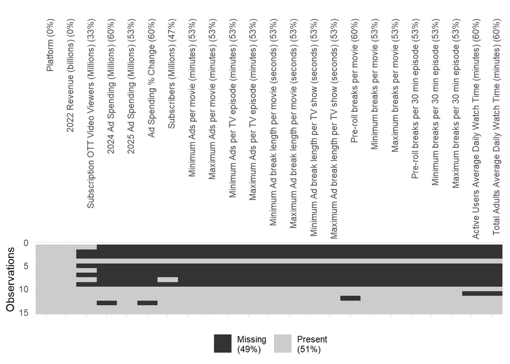

```r
# Identify which columns have the most missing values.

# visualize how many fields are null in each column
vis_miss(master_set_clean) +
  theme(axis.text.x = element_text(angle = 90, hjust = 1))
```

From the visualization, we can see that only 2 columns (Platforms and the Revenue col) have no null fields. For the purpose of this project, we were interested most in high-performing platforms. We will test that such platforms are not missing many values in the next validation step.

```r
# check the number of null values for each platform, ranked by their revenue
platform_missingness <- master_set_clean %>%
  bind_cols(
    miss_case_summary(master_set_clean) %>% select(n_miss, pct_miss)
  ) %>%
  select(Platform, n_miss, pct_miss)


platform_missingness <- master_set_clean %>%
  mutate(
    n_miss = purrr::pmap_int(as.list(.), ~ sum(is.na(c(...)))),
    pct_miss = n_miss / ncol(master_set_clean) * 100
  ) %>%
  select(Platform, n_miss, pct_miss)


platform_missingness$Revenue <- master_set_clean$`2022 Revenue (billions)`

platform_missingness |> arrange(desc(Revenue))
```

```
##              Platform n_miss  pct_miss Revenue
## 1             Netflix      1  4.347826    31.6
## 2  Amazon Prime Video      2  8.695652    17.5
## 3             Disney+      0  0.000000    13.5
## 4             HBO Max      0  0.000000    13.2
## 5          Paramount+      2  8.695652     8.0
## 6                Hulu      0  0.000000     5.7
## 7            AppleTV+     21 91.304348     3.0
## 8               ESPN+     19 82.608696     2.6
## 9               Starz     21 91.304348     1.9
## 10         YouTube TV     20 86.956522     1.8
## 11     DIRECTV Stream     21 91.304348     1.7
## 12            Peacock      0  0.000000     1.5
## 13        Crunchyroll     21 91.304348     1.2
## 14            SlingTV     20 86.956522     1.0
## 15        fuboTV Inc.     21 91.304348     1.0
```

## Write the final dataset into a csv file

```r
#Write the final dataset onto a local desktop folder
write_csv(master_set_clean, "C:\\Users\\rylee\\OneDrive\\Desktop\\401_data.csv")
```